# GLM-examples

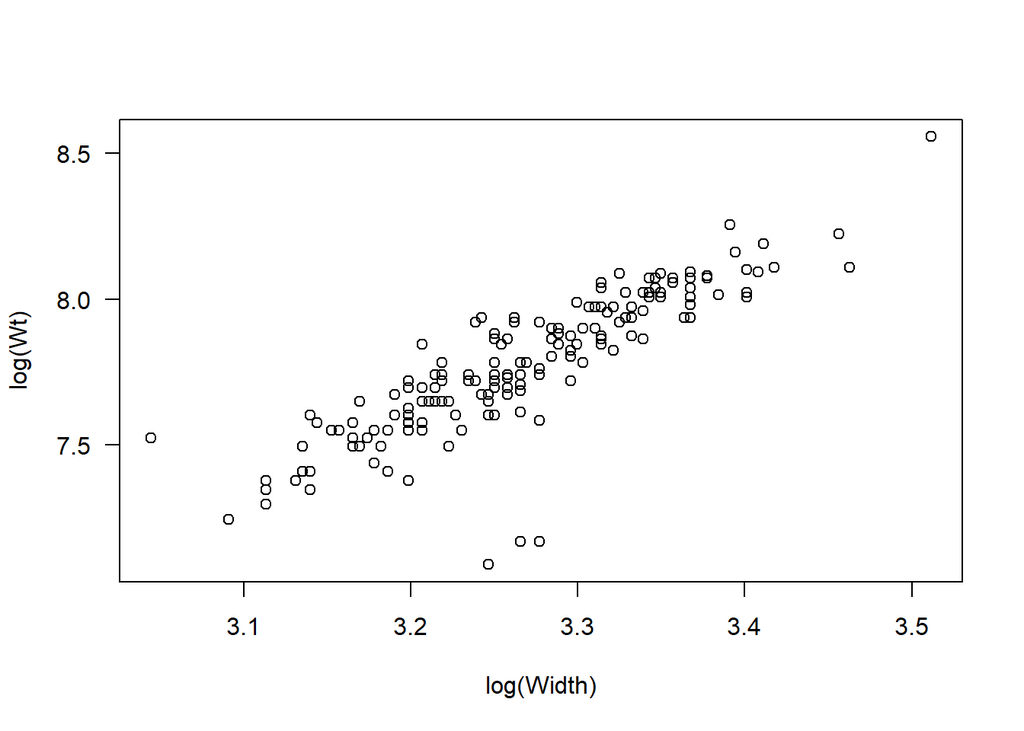

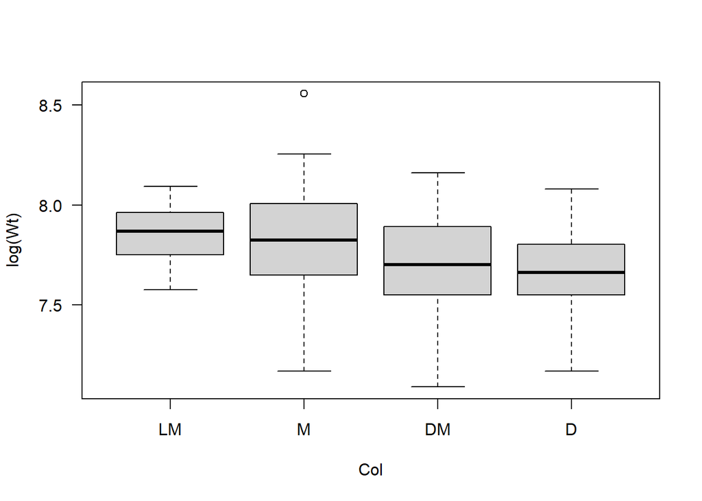

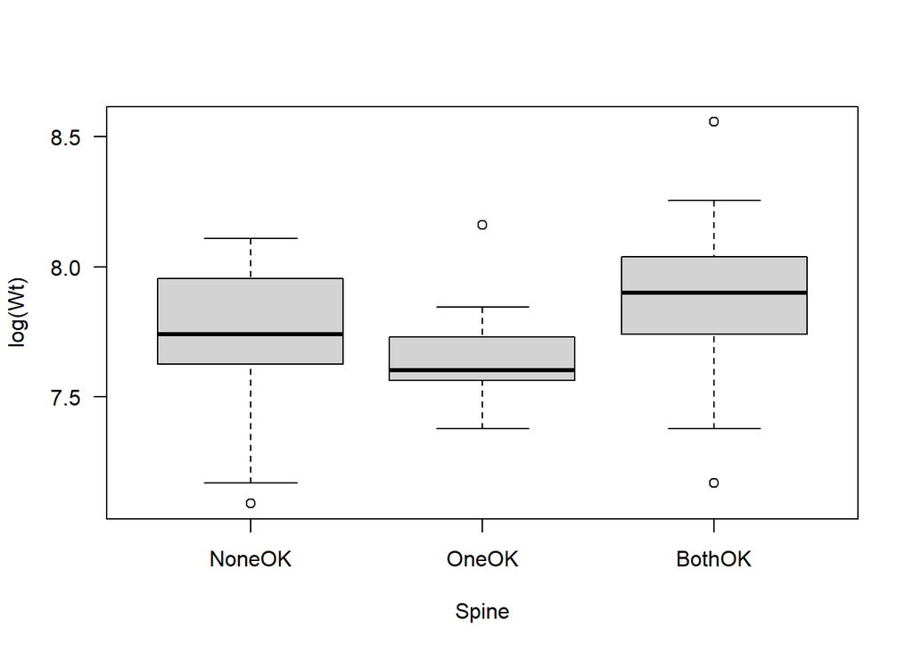

```r
with(hcrabs,{
      plot( log(Wt) ~ log(Width), las=1 )
      plot( log(Wt) ~ Col, las=1 )
      plot( log(Wt) ~ Spine, las=1 )
      })
```

inter-correlation between weight and width was observed; crabs tend to cluster and not to be independent, hence overdispersion was expected:

```r
cr.m1 <- glm(Sat ~ log(Wt) + log(Width) + Spine + Col, family=quasipoisson, data=hcrabs)
anova(cr.m1, test="F")
```

```
## Analysis of Deviance Table
##
## Model: quasipoisson, link: log
##
## Response: Sat
##
## Terms added sequentially (first to last)
##
##
##            Df Deviance Resid. Df Resid. Dev       F    Pr(>F)
## NULL                         172     632.79
## log(Wt)     1   83.084       171     549.71 25.9645 9.429e-07 ***
## log(Width)  1    0.007       170     549.70  0.0023    0.9621
## Spine       2    1.125       168     548.58  0.1758    0.8389
## Col         3    7.630       165     540.95  0.7948    0.4984
## ---
## Signif. codes:  0 '***' 0.001 '**' 0.01 '*' 0.05 '.' 0.1 ' ' 1
```

```r
# check overdispersion
deviance(cr.m1)
```

```
## [1] 540.946
```

```r
df.residual(cr.m1)
```

```
## [1] 165
```

The residual deviance is more than three times the residual degrees of freedom, overdispersion was thus confirmed; only logWt turned out to be significant.

The final step is to refit the quasi-Poisson model or Negative Binomial model with only logWt term and plot diagnostics to identify potential deviations.

# Models for positive continuous data

## modeling positive continuous data

- the boundary at zero limits the left tail of the distribution, thus introduces skewness
- variance approaches 0 as the mean approaches 0, producing interesting mean-variance relationship
  - $V(\mu)=\mu^2$: **gamma** distribution
  - $V(\mu)=\mu^3$: **inverse Gaussian** distribution

pdf for a gamma dist. is given as
$$\mathcal{P}(y;\alpha, \beta)=\frac{y^{\alpha-1}\exp(-y/\beta)}{\Gamma(\alpha)\beta^{\alpha}}, y>0, \alpha>0, \beta>0$$

where $\alpha, \beta$ are the shape and scale parameters, respectively. $E[y]=\alpha \beta, var[y]=\alpha\beta^2$. the canonical link function for a gamma dist. is the inverse link function $\eta=1/\mu$; however, the logarithmic link function is often used because it avoids the need for contrains on the linear predictor in view of $\mu>0$.

writing the gamma pdf in terms of $\mu, \phi$ gives:

$$\mathcal{P}(y;\alpha, \beta)=\frac{y}{\phi\mu}^{1/\phi}\frac{1}{y}\exp(-\frac{y}{\phi\mu})\frac{1}{\Gamma(1/\phi)}$$

example modelling foliage biomass y as a function of tree trunk diameter d:

```r
data(lime)
str(lime)
```

```
## 'data.frame':    385 obs. of  4 variables:
##  $ Foliage: num  0.1 0.2 0.4 0.6 0.6 0.8 1 1.4 1.7 3.5 ...
##  $ DBH    : num  4 6 8 9.6 11.3 13.7 15.4 17.8 18 22 ...
##  $ Age    : int  38 38 46 44 60 56 72 74 68 79 ...
##  $ Origin : Factor w/ 3 levels "Coppice","Natural",..: 2 2 2 2 2 2 2 2 2 2 ...
```

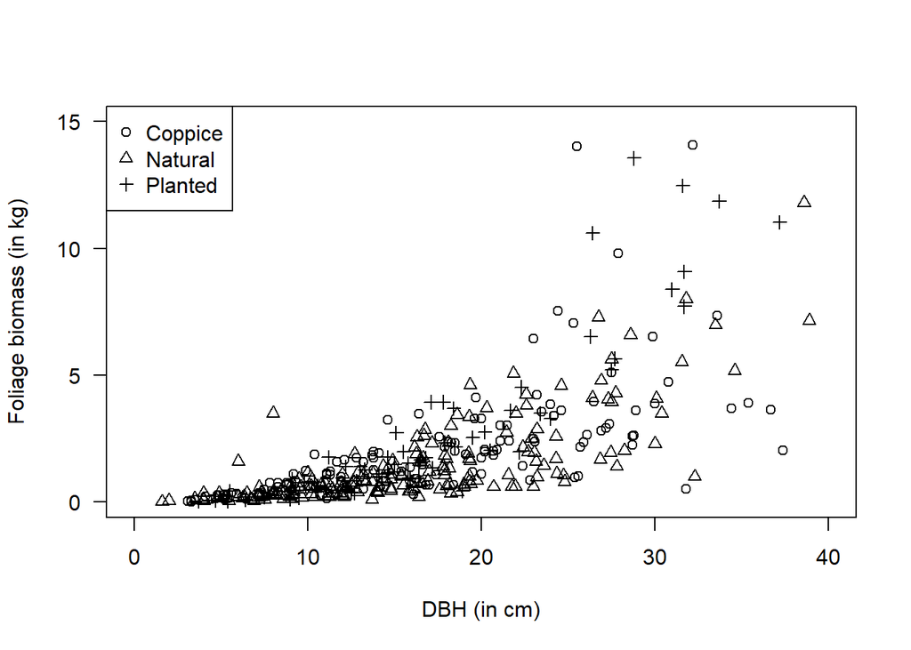

```r
# Plot Foliage against DBH
plot(Foliage ~ DBH, type="n", las=1, xlab="DBH (in cm)",
     ylab="Foliage biomass (in kg)",
     ylim = c(0, 15), xlim=c(0, 40), data=lime)
points(Foliage ~ DBH, data=subset(lime, Origin=="Coppice"),pch=1)
points(Foliage ~ DBH, data=subset(lime, Origin=="Natural"),pch=2)
points(Foliage ~ DBH, data=subset(lime, Origin=="Planted"),pch=3)
legend("topleft", pch=c(1, 2, 3), legend=c("Coppice", "Natural","Planted"))
```

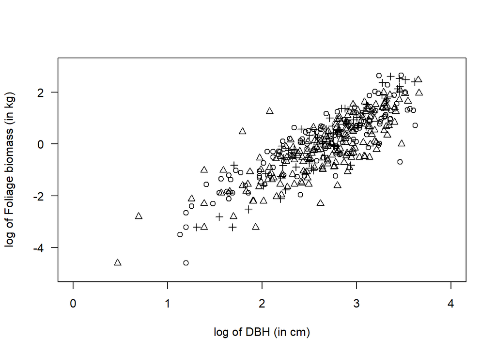

```r
# Plot Foliage against DBH, on log scale
plot( log(Foliage) ~ log(DBH), type="n", las=1,
      xlab="log of DBH (in cm)", ylab="log of Foliage biomass (in kg)",
      ylim = c(-5, 3), xlim=c(0, 4), data=lime)
points( log(Foliage) ~ log(DBH), data=subset(lime, Origin=="Coppice"),pch=1)
points( log(Foliage) ~ log(DBH), data=subset(lime, Origin=="Natural"),pch=2)
points( log(Foliage) ~ log(DBH), data=subset(lime, Origin=="Planted"),pch=3)
```

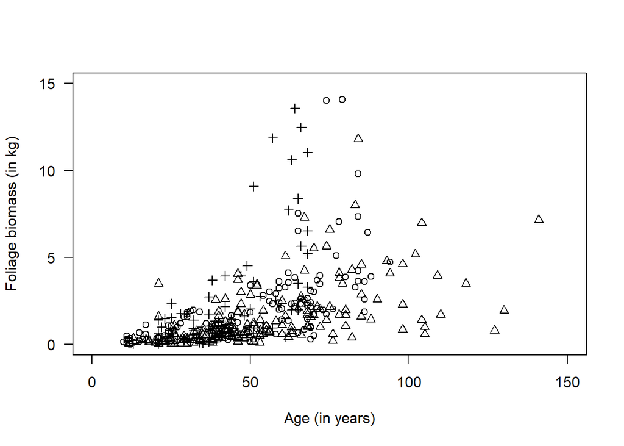

```r
# Plot Foliage against Age
plot(Foliage ~ Age, type="n", las=1,
     xlab="Age (in years)", ylab="Foliage biomass (in kg)",
     ylim = c(0, 15), xlim=c(0, 150), data=lime)
points(Foliage ~ Age, data=subset(lime, Origin=="Coppice"), pch=1)
points(Foliage ~ Age, data=subset(lime, Origin=="Natural"), pch=2)
points(Foliage ~ Age, data=subset(lime, Origin=="Planted"), pch=3)
```

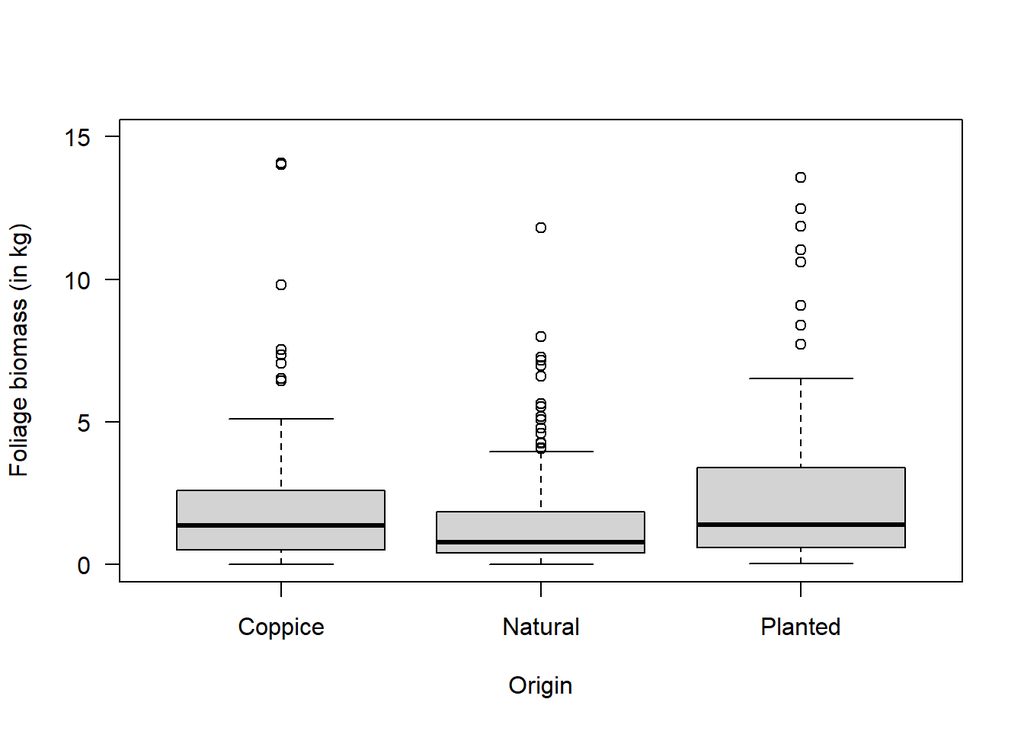

```r
# Plot Foliage against Origin
plot( Foliage ~ Origin, data=lime, ylim=c(0, 15), las=1, ylab="Foliage biomass (in kg)")
```

the response is always positive; the variance in foliage biomass increases as the mean DBH increases;